# Write up of analysis

This is a document outlining a text mining technique. It is designed for reading in every file with a relevant design and seeing if covariance was reported.

First install the package created by L. Colling on GITHUB and load tidyverse.

```r
#install.packages("remotes", repos = "http://cran.us.r-project.org")
#remotes::install_github("ljcolling/jesspkg") # Double colon allows access to exact function in package
library(tidyverse)
library(ggdist)
```

Obtaining a list of all the files (change to own location of files in first "")

```r
list_of_files <- list.files("~/Desktop/pdf_txt/", pattern = "*.txt", recursive = TRUE)
```

Then we create a function that imports file names, journal name, year into a dataframe by splitting the file name into different parts and categorising from this.

```r
get_journal_year <- function(file){
  data.frame(file = file,
             journal = file %>% str_split(string = ., pattern = "/") %>% .[[1]] %>% .[[1]],
             year = file %>% str_split(string = ., pattern = "/") %>% .[[1]] %>% .[[2]])
}
list_of_files <- list_of_files %>% map_df(function(x) get_journal_year(x))
```

We then illustrate the vector of words (word_list) we want to find in the file, which is output into boolean form.

```r
for(i in 1 : length(list_of_files$file)){
  this_file <- list_of_files$file[[i]]
  dat <- jesspkg:::import_file(paste0("~/Desktop/pdf_txt/",this_file))
  has_words <- jesspkg::find_words(text = dat,
                                   word_list = c(" repeated-measure ",
                                                 " repeated measure ",
                                                 " within-subject ",
                                                 " within subject ",
                                                 " within-participant ",
                                                 " within participant ",
                                                 " paired-t ",
                                                 " paired t-test ",
                                                 " dependent sample t-test ",
                                                 " dependent t-test ",
                                                 " dependent t ",
                                                 " repeated measures ANOVA ",
                                                 " repeated-measures ANOVA ",
                                                 " mixed ANOVA ",
                                                 " mixed-ANOVA "
                                   ))
    has_cov <- jesspkg::find_cov(text = dat)
  list_of_files$has_words[i] <- has_words
  list_of_files$has_cov[i] <- has_cov
}
```

Has_cov does word matching to see if covariance is reported, without the addition of other uses of the word (e.g. ANCOVA).

## Calculating overall numbers of covariance and designs looking into

```r
all_designs <- list_of_files[,4]
amount_using_design <- length(all_designs[all_designs == TRUE])
amount_using_design
```

```
## [1] 170
```

Therefore 170 out of 928 used the design we are interested in.

```r
reported_ornot <- list_of_files[,5]
amount_reporting_cov <- length(reported_ornot[reported_ornot == TRUE])
amount_reporting_cov
```

```
## [1] 46
```

Therefore 46 out of 928 papers reported covariance.

## Total of each journal that reported relevant designs

# Developmental Science

```r
ds <- list_of_files %>% filter(journal == "dev_sci")
ds_des <- ds[,4]
total_ds_design <- length(ds_des[ds_des == TRUE])
total_ds_design
```

```
## [1] 53
```

# Journal of Experimental Social Psychology

```r
JESP <- list_of_files %>% filter(journal == "journal_exp_soc_psy")
JESP_des <- JESP[,4]
total_JESP_design <- length(JESP_des[JESP_des == TRUE])
total_JESP_design
```

```
## [1] 74
```

# Journal of Memory and Lanuage

```r
jml <- list_of_files %>% filter(journal == "j_mem_lang")
jml_des <- jml[,4]
total_jml_design <- length(jml_des[jml_des == TRUE])
total_jml_design
```

```
## [1] 43
```

## Developmental science totals for relevant design, grouped by year

Amount of dev sci using relevant design in 2009

```r
ds_2009 <- list_of_files %>% filter(journal == "dev_sci", year == "2009")
ds_2009_des <- ds_2009[,4]
total_ds_design_2009 <- length(ds_2009_des[ds_2009_des == TRUE])
total_ds_design_2009
```

```
## [1] 30
```

Amount of dev_sci using relevant design in 2014

```r
ds_2014 <- list_of_files %>% filter(journal == "dev_sci", year == "2014")
ds_2014_des <- ds_2014[,4]
total_ds_design_2014 <- length(ds_2014_des[ds_2014_des == TRUE])
total_ds_design_2014
```

```
## [1] 15
```

Amount of dev_sci using relevant design in 2019

```r
ds_2019 <- list_of_files %>% filter(journal == "dev_sci", year == "2019")
ds_2019_des <- ds_2019[,4]
total_ds_design_2019 <- length(ds_2019_des[ds_2019_des == TRUE])
total_ds_design_2019
```

```
## [1] 8
```

## Journal of Experimental Social Psychology totals for relevant design, grouped by year

Amount of JESP using relevant design in 2009

```r
JESP_2009 <- list_of_files %>% filter(journal == "journal_exp_soc_psy", year == "2009")
JESP_2009_des <- JESP_2009[,4]
total_JESP_design_2009 <- length(JESP_2009_des[JESP_2009_des == TRUE])
total_JESP_design_2009
```

```
## [1] 21
```

Amount of JESP using relevant design in 2014

```r
JESP_2014 <- list_of_files %>% filter(journal == "journal_exp_soc_psy", year == "2014")
JESP_2014_des <- JESP_2014[,4]
total_JESP_design_2014 <- length(JESP_2014_des[JESP_2014_des == TRUE])
total_JESP_design_2014
```

```
## [1] 24
```

Amount of JESP using relevant design in 2019

```r
JESP_2019 <- list_of_files %>% filter(journal == "journal_exp_soc_psy", year == "2019")
JESP_2019_des <- JESP_2019[,4]
total_JESP_design_2019 <- length(JESP_2019_des[JESP_2019_des == TRUE])
total_JESP_design_2019
```

```
## [1] 29
```

## Journal of Memory and Language for relevant design, grouped by year

Amount of jml using relevant design in 2009

```r
jml_2009 <- list_of_files %>% filter(journal == "j_mem_lang", year == "2009")
jml_2009_des <- jml_2009[,4]
total_jml_design_2009 <- length(jml_2009_des[jml_2009_des == TRUE])
total_jml_design_2009
```

```
## [1] 8
```

Amount of jml using relevant design in 2014

```r
jml_2014 <- list_of_files %>% filter(journal == "j_mem_lang", year == "2014")
jml_2014_des <- jml_2014[,4]
total_jml_design_2014 <- length(jml_2014_des[jml_2014_des == TRUE])
total_jml_design_2014
```

```
## [1] 14
```

Amount of jml using relevant design in 2019

```r
jml_2019 <- list_of_files %>% filter(journal == "j_mem_lang", year == "2019")
jml_2019_des <- jml_2019[,4]
total_jml_design_2019 <- length(jml_2019_des[jml_2019_des == TRUE])
total_jml_design_2019
```

```
## [1] 21
```

## Calculating those that did NOT report covariance, when it should have in each journal and year

```r
list_of_files$reported_check <- ifelse(list_of_files$has_words > list_of_files$has_cov, 'Not reported',
                     ifelse(list_of_files$has_words < list_of_files$has_cov, 'NA', 'NA'))
summary_table <- list_of_files %>% dplyr::group_by(journal, year, reported_check) %>% dplyr::summarise(n = n())
summary_table %>% tidyr::pivot_wider(id_cols = 1:2, names_from = 3, values_from =4)
```

```
## # A tibble: 9 x 4
## # Groups:   journal, year [9]
##   journal             year   `NA` `Not reported`
##   <chr>               <chr> <int>          <int>
## 1 dev_sci             2009     68             29
## 2 dev_sci             2014     71             15
## 3 dev_sci             2019    125              8
## 4 j_mem_lang          2009     35              8
## 5 j_mem_lang          2014     55             13
## 6 j_mem_lang          2019     47             19
## 7 journal_exp_soc_psy 2009    156             21
## 8 journal_exp_soc_psy 2014    102             23
## 9 journal_exp_soc_psy 2019    107             26
```

This creates a new column ‘reported_check’ in list_of_files showing which covariance not reported, given that the certain design is used. This is then shown in this summary table as a break down of each journal/year.

## Bayesian analysis of the numbers

First need to install relevant packages…

```r
#install.packages("remotes", repos = "http://cran.us.r-project.org")
#remotes::install_github("ljcolling/bayesbinom", dependencies = FALSE)
#install.packages("ggplot2", repos = "http://cran.us.r-project.org")
#install.packages("purrr", repos = "http://cran.us.r-project.org")
#install.packages("ggdist", repos = "http://cran.us.r-project.org")
```

Then packages can be loaded.

```r
library(bayesbinom)
#library(tidyverse)
```

These packages are used for creating graphs.

```r
#install.packages("ggdist", repos = "http://cran.us.r-project.org")
library(ggdist)
```

## For general

```r
all_cov <- binom_proportions(successes = 8,
                           trials = 170,
                           shape1 = 1,
                           shape2 = 1)
summary(all_cov)
```

```
##        mode lower_limit upper_limit width
## 1 0.0461316  0.03764840  0.05925250  0.50
## 2 0.0461316  0.02019613  0.08718233  0.96
## 3 0.0461316  0.01750706  0.10192431  0.99
```

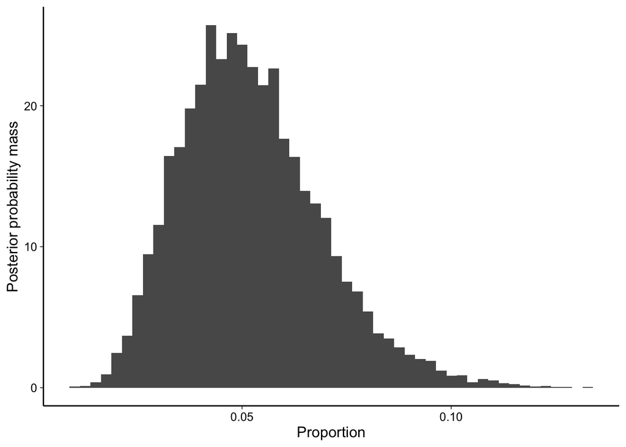

```r
all_cov$posterior_histogram(bins = 50) + theme_linedraw() +
  labs(x = "Proportion", y = "Posterior probability mass") +
  theme(text=element_text(size=12,  family="Arial"),
        panel.grid.major=element_blank(),
        panel.grid.minor=element_blank(),
        panel.border=element_blank(),
        axis.line=element_line(),
        legend.title=element_blank())
```

```r
ggsave("all.jpeg", width = 7, height = 5)
```

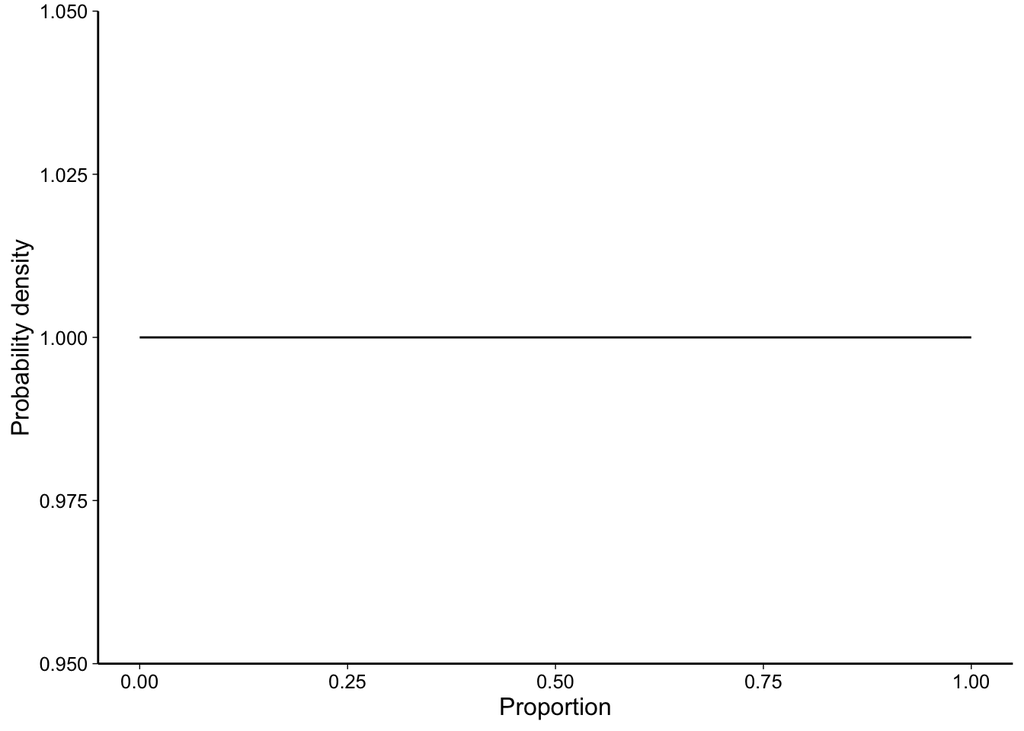

```r
all_cov$prior_plot + theme_linedraw() + labs(x = "Proportion", y = "Probability density") +   theme(text=element_text(size=12,  family="Arial"),
        panel.grid.major=element_blank(),
        panel.grid.minor=element_blank(),
        panel.border=element_blank(),
        axis.line=element_line(),
        legend.title=element_blank())
```

```r
ggsave("prior.jpeg", width = 7, height = 5)
```

## For years

For our first estimate our proportion will be 1 out of 59, for 2009 and 2 out of 53 for 2014. We’ll use a Beta(1, 1) prior. This is a uniform prior that assigns equal weight to all proportions between 0 and 1.

```r
the2009_post <- binom_proportions(successes = 1,
                           trials = 59,
                           shape1 = 1,
                           shape2 = 1)

the2014_post <- binom_proportions(successes = 2,
                           trials = 53,
                           shape1 = 1,
                           shape2 = 1)
the2019_post <- binom_proportions(successes = 5,
                           trials = 58,
                           shape1 = 1,
                           shape2 = 1)
```

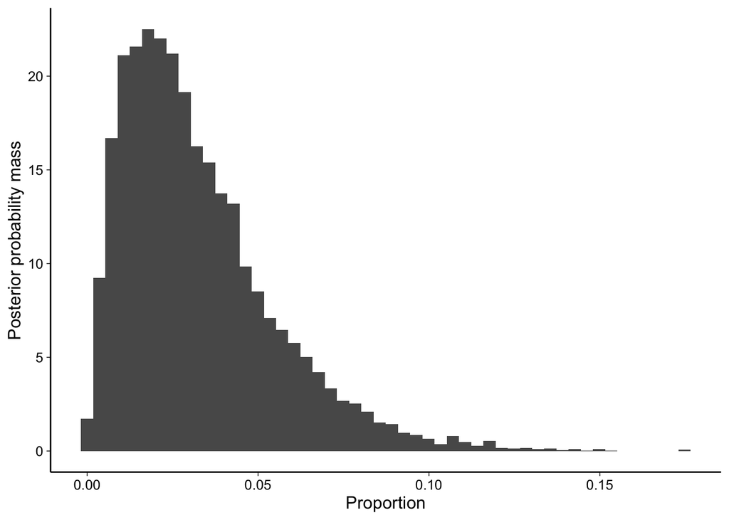

```r
the2009_post$posterior_histogram(bins = 50) + theme_linedraw() +
  labs(x = "Proportion", y = "Posterior probability mass") +
  theme(text=element_text(size=12,  family="Arial"),
        panel.grid.major=element_blank(),
        panel.grid.minor=element_blank(),
        panel.border=element_blank(),
        axis.line=element_line(),
        legend.title=element_blank())
```

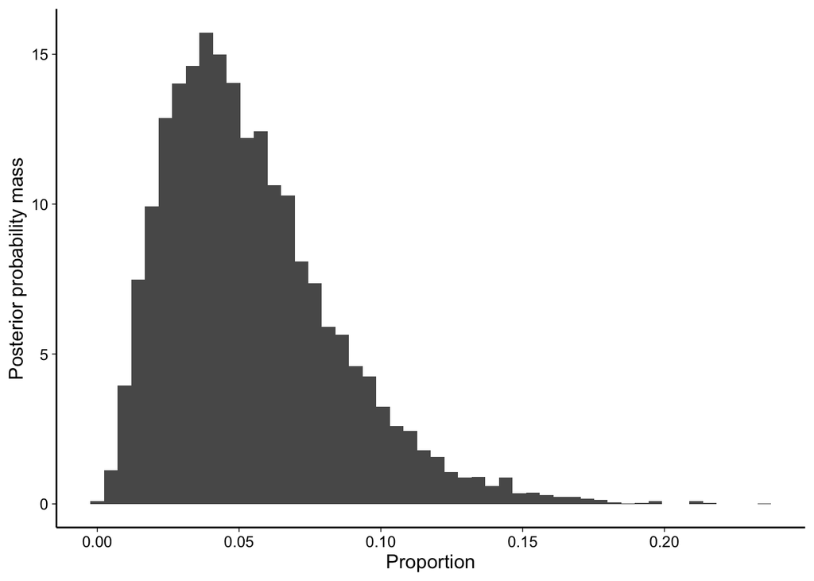

```r
ggsave("2009post.jpeg", width = 7, height = 5)
the2014_post$posterior_histogram(bins = 50) + theme_linedraw() +
  labs(x = "Proportion", y = "Posterior probability mass") +
  theme(text=element_text(size=12,  family="Arial"),
        panel.grid.major=element_blank(),
        panel.grid.minor=element_blank(),
        panel.border=element_blank(),
        axis.line=element_line(),
        legend.title=element_blank())
```

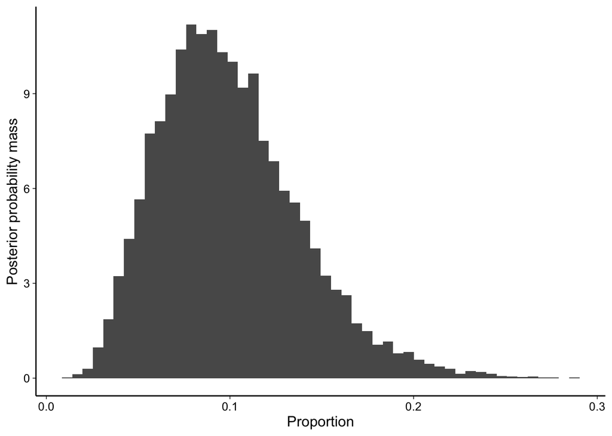

```r
ggsave("2014post.jpeg", width = 7, height = 5)
the2019_post$posterior_histogram(bins = 50) + theme_linedraw() +
  labs(x = "Proportion", y = "Posterior probability mass") +
  theme(text=element_text(size=12,  family="Arial"),
        panel.grid.major=element_blank(),
        panel.grid.minor=element_blank(),
        panel.border=element_blank(),
        axis.line=element_line(),
        legend.title=element_blank())
```

```r
ggsave("2019post.jpeg", width = 7, height = 5)
```

```r
posterior_difference_09_14 <- the2009_post-the2014_post
df_09_14 <- data.frame(x = posterior_difference_09_14$posterior_samples)
```

Converted posterior difference into a data frame, then this was put into a ggplot, two independent binomial proportions

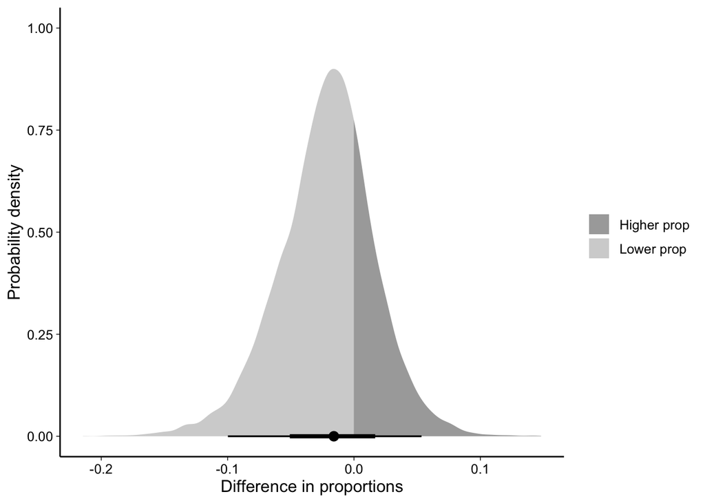

```r
df_09_14 %>%
  ggplot(aes(x = x, fill = stat(x < 0))) +
  ggdist::stat_histinterval(point_interval = mode_hdi, slab_type = "pdf") +
  theme_linedraw() +
  labs(y = "Probability density", x = "Difference in proportions") +
  theme(text=element_text(size=12,  family="Arial"),
        panel.grid.major=element_blank(),
        panel.grid.minor=element_blank(),
        panel.border=element_blank(),
        axis.line=element_line(),
        legend.title=element_blank()) +
  scale_fill_manual(values = c("darkgray", "lightgray"),
                  name = "diff < 0", labels = c("Higher prop","Lower prop"))
```

```r
ggsave("09_14.jpeg", width = 7, height = 5)
```

```r
below_zero_09_14 <- sum(posterior_difference_09_14$posterior_samples < 0) / length(posterior_difference_09_14$posterior_samples)
below_zero_09_14
```

```
## [1] 0.7274
```

```r
the2019_post <- binom_proportions(successes = 5,
                           trials = 58,
                           shape1 = 1,
                           shape2 = 1)
summary(the2019_post)
```

```
##         mode lower_limit upper_limit width
## 1 0.08354467  0.06706417   0.1159257  0.50
## 2 0.08354467  0.03163781   0.1819039  0.96
## 3 0.08354467  0.02464146   0.2147588  0.99
```

```r
posterior_difference_14_19 <- the2014_post-the2019_post
df_14_19 <- data.frame(x = posterior_difference_14_19$posterior_samples)
```

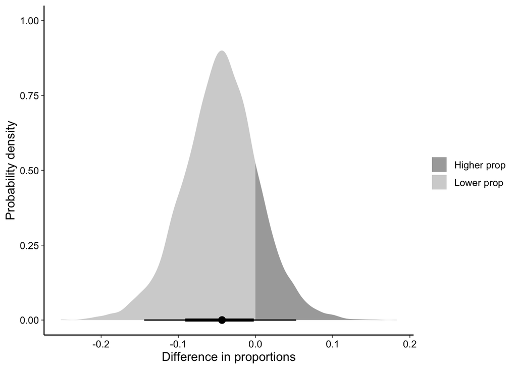

```r
df_14_19 %>%
  ggplot(aes(x = x, fill = stat(x < 0))) +
  stat_histinterval(point_interval = mode_hdi, slab_type = "pdf") +
  theme_linedraw() +
  labs(y = "Probability density", x = "Difference in proportions") +
  theme(text=element_text(size=12,  family="Arial"),
        panel.grid.major=element_blank(),
        panel.grid.minor=element_blank(),
        panel.border=element_blank(),
        axis.line=element_line(),
        legend.title=element_blank()) +
  scale_fill_manual(values = c("darkgray", "lightgray"),
                  name = "diff < 0", labels = c("Higher prop","Lower prop"))
```

```r
ggsave("14_19.jpeg", width = 7, height = 5)
```

```r
below_zero <- sum(posterior_difference_14_19$posterior_samples < 0) / length(posterior_difference_14_19$posterior_samples)
below_zero
```

```
## [1] 0.8351
```

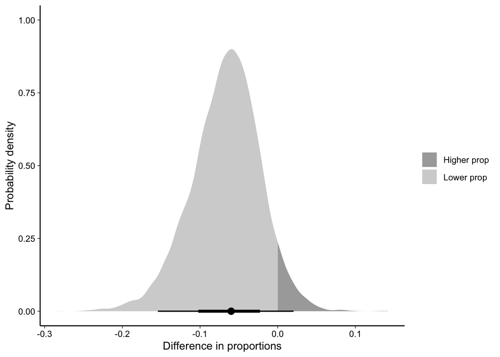

```r
posterior_difference_09_19 <- the2009_post-the2019_post
df_09_19 <- data.frame(x = posterior_difference_09_19$posterior_samples)
df_09_19 %>%
  ggplot(aes(x = x, fill = stat(x < 0))) +
  stat_histinterval(point_interval = mode_hdi, slab_type = "pdf") +
  theme_linedraw() +
  labs(y = "Probability density", x = "Difference in proportions") +
  theme(text=element_text(size=11,  family="Arial"),
        panel.grid.major=element_blank(),
        panel.grid.minor=element_blank(),
        panel.border=element_blank(),
        axis.line=element_line(),
        legend.title=element_blank()) +
  scale_fill_manual(values = c("darkgray", "lightgray"),
                  name = "diff < 0", labels = c("Higher prop","Lower prop"))
```

```r
ggsave("09_19.jpeg", width = 7, height = 5)
```

```r
below_zero <- sum(posterior_difference_09_19$posterior_samples < 0) / length(posterior_difference_09_19$posterior_samples)
below_zero
```

```
## [1] 0.948
```

## For journals

```r
dev_sci_post <- binom_proportions(successes = 3,
                           trials = 43,
                           shape1 = 1,
                           shape2 = 1)
mem_lang_post <- binom_proportions(successes = 1,
                           trials = 53,
                           shape1 = 1,
                           shape2 = 1)
jesp_post <- binom_proportions(successes = 4,
                           trials = 74,
                           shape1 = 1,
                           shape2 = 1)
summary(dev_sci_post)
```

```
##         mode lower_limit upper_limit width
## 1 0.06803999  0.04342871  0.09560629  0.50
## 2 0.06803999  0.01689111  0.17669148  0.96
## 3 0.06803999  0.01200582  0.21546450  0.99
```

```r
summary(mem_lang_post)
```

```
##        mode lower_limit upper_limit width
## 1 0.0208001 0.006935769  0.03352428  0.50
## 2 0.0208001 0.000478895  0.08886909  0.96
## 3 0.0208001 0.000478895  0.11332432  0.99
## 4 0.0208001 0.115939942  0.12079753  0.99
```

```r
summary(jesp_post)
```

```
##         mode lower_limit upper_limit width
## 1 0.05262308  0.04035322  0.07578703  0.50
## 2 0.05262308  0.01621310  0.12513762  0.96
## 3 0.05262308  0.01083938  0.15089185  0.99
```

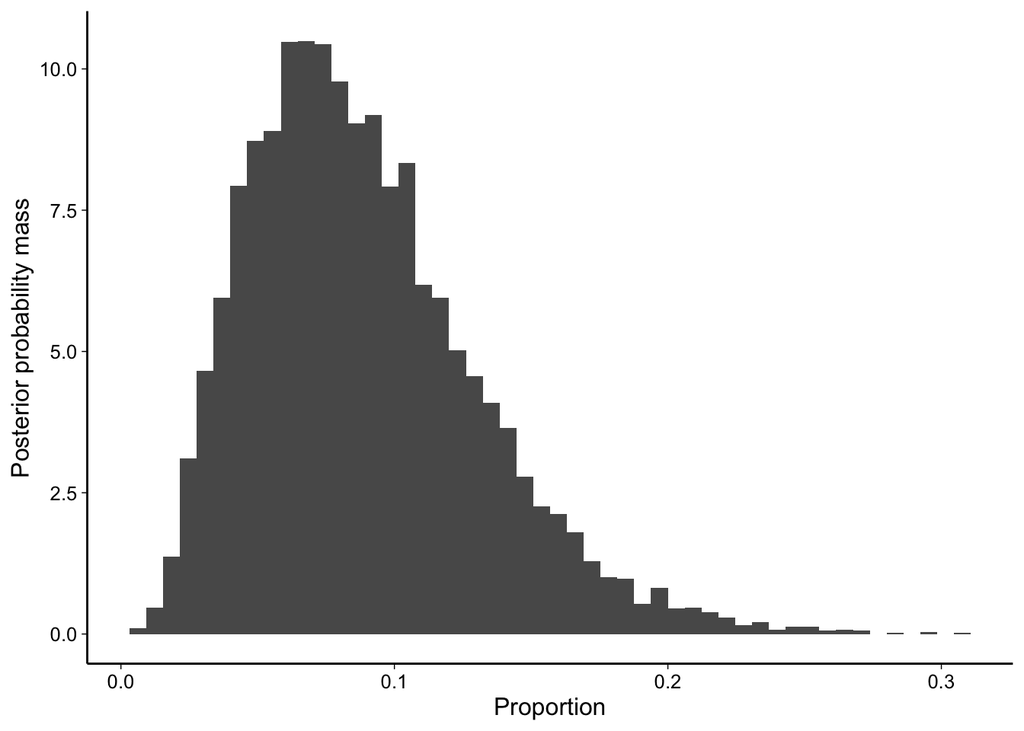

```r
dev_sci_post$posterior_histogram(bins = 50) + theme_linedraw() +
  labs(x = "Proportion", y = "Posterior probability mass") +
  theme(text=element_text(size=12,  family="Arial"),
        panel.grid.major=element_blank(),
        panel.grid.minor=element_blank(),
        panel.border=element_blank(),
        axis.line=element_line(),
        legend.title=element_blank())
```

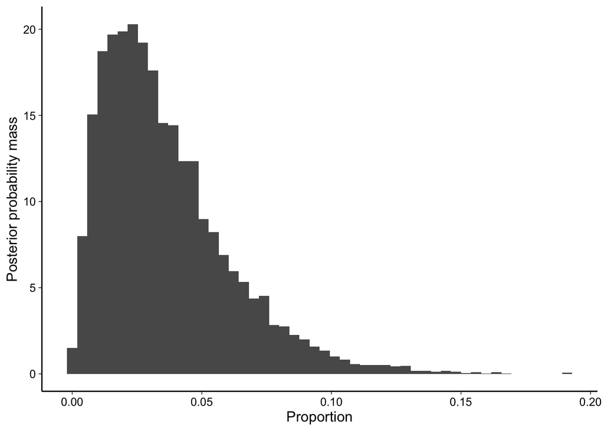

```r
ggsave("dev_sci_post.jpeg", width = 7, height = 5)
mem_lang_post$posterior_histogram(bins = 50) + theme_linedraw() +
  labs(x = "Proportion", y = "Posterior probability mass") +
  theme(text=element_text(size=12,  family="Arial"),
        panel.grid.major=element_blank(),
        panel.grid.minor=element_blank(),
        panel.border=element_blank(),
        axis.line=element_line(),
        legend.title=element_blank())
```

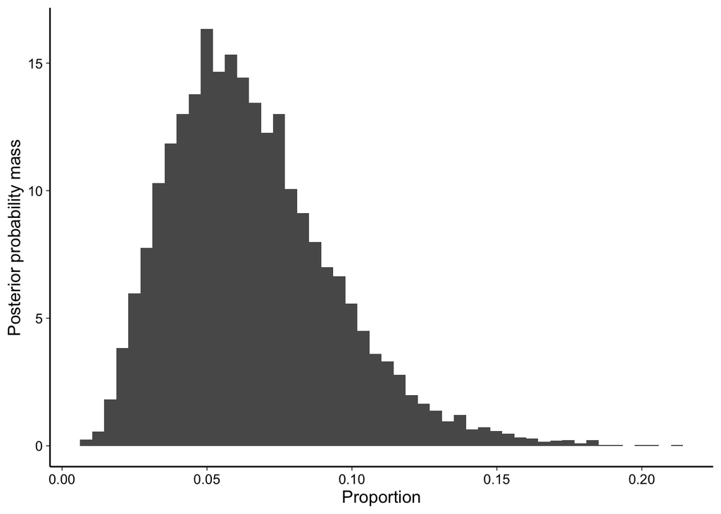

```r
ggsave("mem_lang_post.jpeg", width = 7, height = 5)
jesp_post$posterior_histogram(bins = 50) + theme_linedraw() +
  labs(x = "Proportion", y = "Posterior probability mass") +
  theme(text=element_text(size=12,  family="Arial"),
        panel.grid.major=element_blank(),
        panel.grid.minor=element_blank(),
        panel.border=element_blank(),
        axis.line=element_line(),
        legend.title=element_blank())
```

```r
ggsave("jesp_post.jpeg", width = 7, height = 5)
```

```r
posterior_difference_m_d <- dev_sci_post-mem_lang_post
df_m_d <- data.frame(x = posterior_difference_m_d$posterior_samples)
```

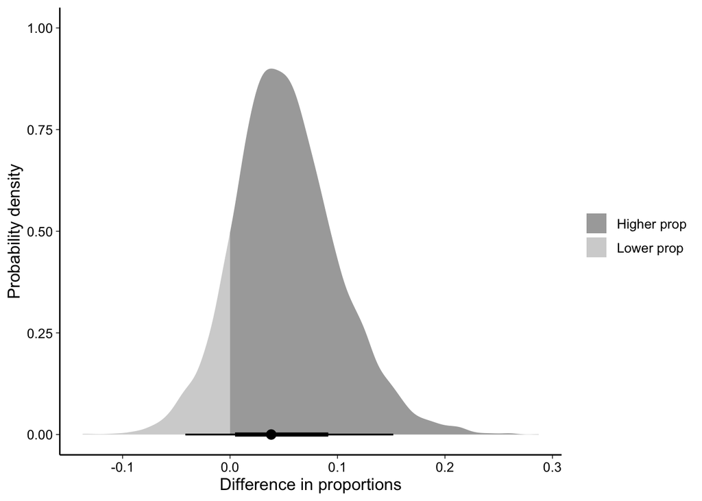

```r
df_m_d %>%
  ggplot(aes(x = x, fill = stat(x < 0))) +
  stat_histinterval(point_interval = mode_hdi, slab_type = "pdf") +
  theme_linedraw() +
  labs(y = "Probability density", x = "Difference in proportions") +
  theme(text=element_text(size=12,  family="Arial"),
        panel.grid.major=element_blank(),
        panel.grid.minor=element_blank(),
        panel.border=element_blank(),
        axis.line=element_line(),
        legend.title=element_blank()) +
  scale_fill_manual(values = c("darkgray", "lightgray"),
                  name = "diff < 0", labels = c("Higher prop","Lower prop"))
```

```r
ggsave("m_d.jpeg", width = 7, height = 5)
```

```r
below_zero <- sum(posterior_difference_m_d$posterior_samples < 0) / length(posterior_difference_m_d$posterior_samples)
below_zero
```

```
## [1] 0.1229
```

```r
posterior_difference_m_j <- mem_lang_post-jesp_post
df_m_j <- data.frame(x = posterior_difference_m_j$posterior_samples)
```

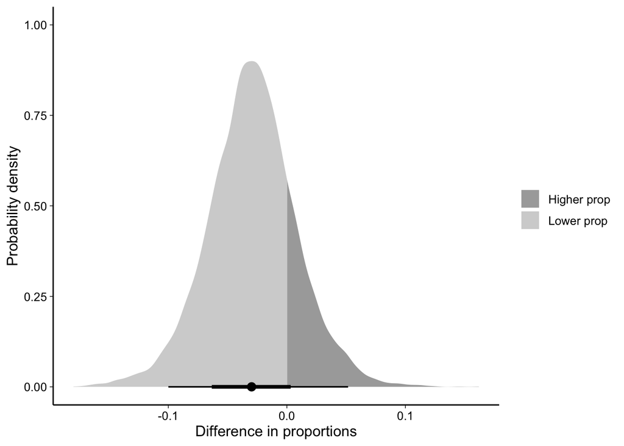

```r
df_m_j %>%
  ggplot(aes(x = x, fill = stat(x < 0))) +
  stat_histinterval(point_interval = mode_hdi, slab_type = "pdf") +
  theme_linedraw() +
  labs(y = "Probability density", x = "Difference in proportions") +
  theme(text=element_text(size=12,  family="Arial"),
        panel.grid.major=element_blank(),
        panel.grid.minor=element_blank(),
        panel.border=element_blank(),
        axis.line=element_line(),
        legend.title=element_blank()) +
  scale_fill_manual(values = c("darkgray", "lightgray"),
                  name = "diff < 0", labels = c("Higher prop","Lower prop"))
```

```r
ggsave("m_j.jpeg", width = 7, height = 5)
```

```r
below_zero <- sum(posterior_difference_m_j$posterior_samples < 0) / length(posterior_difference_m_j$posterior_samples)
below_zero
```

```
## [1] 0.8033
```

```r
posterior_difference_d_j <- dev_sci_post-jesp_post
df_d_j <- data.frame(x = posterior_difference_d_j$posterior_samples)
```

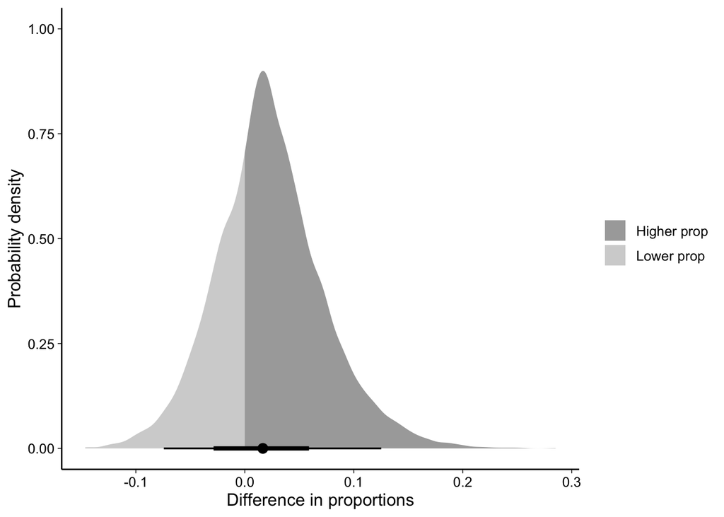

```r
df_d_j %>%
  ggplot(aes(x = x, fill = stat(x < 0))) +
  stat_histinterval(point_interval = mode_hdi, slab_type = "pdf") +
  theme_linedraw() +
  labs(y = "Probability density", x = "Difference in proportions") +
  theme(text=element_text(size=12,  family="Arial"),
        panel.grid.major=element_blank(),
        panel.grid.minor=element_blank(),
        panel.border=element_blank(),
        axis.line=element_line(),
        legend.title=element_blank()) +
  scale_fill_manual(values = c("darkgray", "lightgray"),
                  name = "diff < 0", labels = c("Higher prop","Lower prop"))
```

```r
ggsave("d_j.jpeg", width = 7, height = 5)
```

```r
below_zero <- sum(posterior_difference_d_j$posterior_samples < 0) / length(posterior_difference_d_j$posterior_samples)
below_zero
```

```
## [1] 0.308
```

## Example of how the random selection was completed

```r
# jesp_2014 <- list_of_files %>% filter(journal == "journal_exp_soc_psy", year == "2014", has_words == "TRUE", reported_check == "Not reported")
# jesp_2014
# ran_jesp_2014 <- jesp_2014[sample(nrow(jesp_2014), 10),]
# ran_jesp_2014
```

## Manual checking Bayesian

```r
actual <- binom_proportions(successes = 40,
                           trials = 94,
                           shape1 = 1,
                           shape2 = 1)
summary(actual)
```

```
##        mode lower_limit upper_limit width
## 1 0.4293047   0.3869658   0.4545258  0.50
## 2 0.4293047   0.3246220   0.5311238  0.96
## 3 0.4293047   0.2996938   0.5515934  0.99
```

```r
notactual <- binom_proportions(successes = 54,
                           trials = 94,
                           shape1 = 1,
                           shape2 = 1)
summary(notactual)
```

```
##        mode lower_limit upper_limit width
## 1 0.5706953   0.5454742   0.6130342  0.50
## 2 0.5706953   0.4688762   0.6753780  0.96
## 3 0.5706953   0.4484066   0.7003062  0.99
```

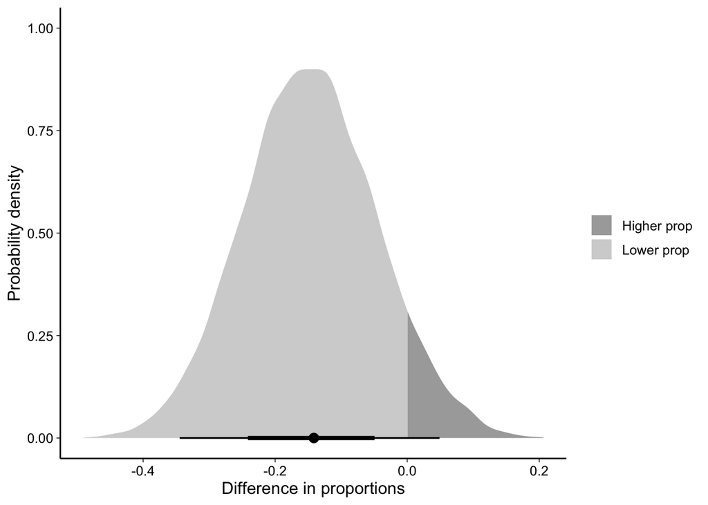

```r
posterior_difference_act_not <- actual - notactual
df_act_not <- data.frame(x = posterior_difference_act_not$posterior_samples)

df_act_not %>%
  ggplot(aes(x = x, fill = stat(x < 0))) +
  stat_histinterval(point_interval = mode_hdi, slab_type = "pdf") +
  theme_linedraw() +
  labs(y = "Probability density", x = "Difference in proportions") +
  theme(text=element_text(size=12,  family="Arial"),
        panel.grid.major=element_blank(),
        panel.grid.minor=element_blank(),
        panel.border=element_blank(),
        axis.line=element_line(),
        legend.title=element_blank()) +
  scale_fill_manual(values = c("darkgray", "lightgray"),
                  name = "diff < 0", labels = c("Higher prop","Lower prop"))
```

```r
ggsave("act_not.jpeg", width = 7, height = 5)

below_zero <- sum(posterior_difference_act_not$posterior_samples < 0) / length(posterior_difference_act_not$posterior_samples)
below_zero
```

```
## [1] 0.9238
```

```r
man_2009 <- binom_proportions(successes = 13,
                           trials = 29,
                           shape1 = 1,
                           shape2 = 1)
man_2019 <- binom_proportions(successes = 12,
                           trials = 33,
                           shape1 = 1,
                           shape2 = 1)
summary(man_2009)
```

```
##        mode lower_limit upper_limit width
## 1 0.4422558   0.3808300   0.5007183  0.50
## 2 0.4422558   0.2756514   0.6336220  0.96
## 3 0.4422558   0.2377554   0.6689848  0.99
```

```r
summary(man_2019)
```

```
##        mode lower_limit upper_limit width
## 1 0.3574805   0.3080185   0.4170819  0.50
## 2 0.3574805   0.2071088   0.5347236  0.96
## 3 0.3574805   0.1851690   0.5821089  0.99
```

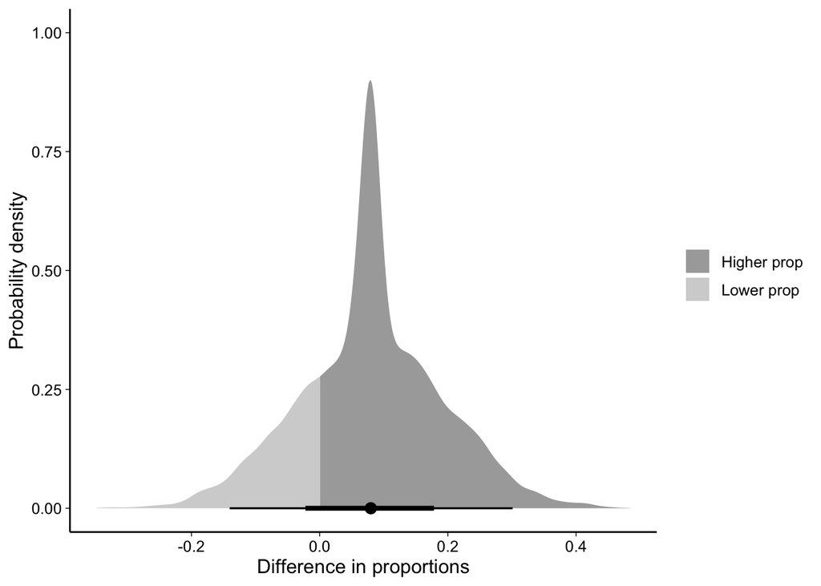

```r
posterior_differenceman2009_2019 <- man_2009-man_2019
df_man2009_2019 <- data.frame(x = posterior_differenceman2009_2019$posterior_samples)

df_man2009_2019 %>%
  ggplot(aes(x = x, fill = stat(x < 0))) +
  stat_histinterval(point_interval = mode_hdi, slab_type = "pdf") +
  theme_linedraw() +
  labs(y = "Probability density", x = "Difference in proportions") +
  theme(text=element_text(size=12,  family="Arial"),
        panel.grid.major=element_blank(),
        panel.grid.minor=element_blank(),
        panel.border=element_blank(),
        axis.line=element_line(),
        legend.title=element_blank()) +
  scale_fill_manual(values = c("darkgray", "lightgray"),
                  name = "diff < 0", labels = c("Higher prop","Lower prop"))
```

```r
ggsave("man_2009_2019.jpeg", width = 7, height = 5)

below_zero <- sum(posterior_differenceman2009_2019$posterior_samples < 0) / length(posterior_differenceman2009_2019$posterior_samples)
below_zero
```

```
## [1] 0.2142
```

```r
man_dev_sci <- binom_proportions(successes = 11,
                           trials = 29,
                           shape1 = 1,
                           shape2 = 1)
man_jesp <- binom_proportions(successes = 19,
                           trials = 34,
                           shape1 = 1,
                           shape2 = 1)
man_mem_lang <- binom_proportions(successes = 12,
                           trials = 31,
                           shape1 = 1,
                           shape2 = 1)
summary(man_dev_sci)
```

```
##        mode lower_limit upper_limit width
## 1 0.3719242   0.3189738   0.4358381  0.50
## 2 0.3719242   0.2095482   0.5597507  0.96
## 3 0.3719242   0.1894423   0.6119083  0.99
```

```r
summary(man_jesp)
```

```
##        mode lower_limit upper_limit width
## 1 0.5638131   0.5100390   0.6210397  0.50
## 2 0.5638131   0.3876238   0.7206533  0.96
## 3 0.5638131   0.3548961   0.7561665  0.99
```

```r
summary(man_mem_lang)
```

```
##        mode lower_limit upper_limit width
## 1 0.3801445   0.3275865   0.4412587  0.50
## 2 0.3801445   0.2229223   0.5645462  0.96
## 3 0.3801445   0.1972810   0.6087304  0.99
```